# Course - Exploratory Data Analysis

###### Author: Sana Rasheed

###### Student: Rashida Parveen

###### Date: October 20, 2020

###### Submission_Date:Aug15, 2021

##### NOTE:

1. Enter student name and date to your exercise submission date in above.
2. Your code MUST execute without errors.
3. You can add more lines in your code as required.

## Section 1: Summary Statistics

### Question 1

**The dataset is loaded for you. Perform the following tasks:**

1. Using the airquality dataset, generate the five-point summary through the appropriate function.
2. Visualize the data for temperature through histogram. Add color and labels.
3. Visualize the distribution of data for Wind. Add colors and labels.
4. Visualize the relationship between Solar.R and Ozone. Use scatterplot and circular red markers to identify the points.

```r
library(datasets)
head(airquality)
```

| Ozone | Solar.R | Wind | Temp | Month | Day |
| --- | --- | --- | --- | --- | --- |
| 41 | 190 | 7.4 | 67 | 5 | 1 |
| 36 | 118 | 8.0 | 72 | 5 | 2 |
| 12 | 149 | 12.6 | 74 | 5 | 3 |
| 18 | 313 | 11.5 | 62 | 5 | 4 |
| NA | NA | 14.3 | 56 | 5 | 5 |
| 28 | NA | 14.9 | 66 | 5 | 6 |

```r
#1.Using the airquality dataset, generate the five-point summary through the appropriate function.
summary(airquality$Day)
```

```
   Min. 1st Qu.  Median    Mean 3rd Qu.    Max.
    1.0     8.0    16.0    15.8    23.0    31.0
```

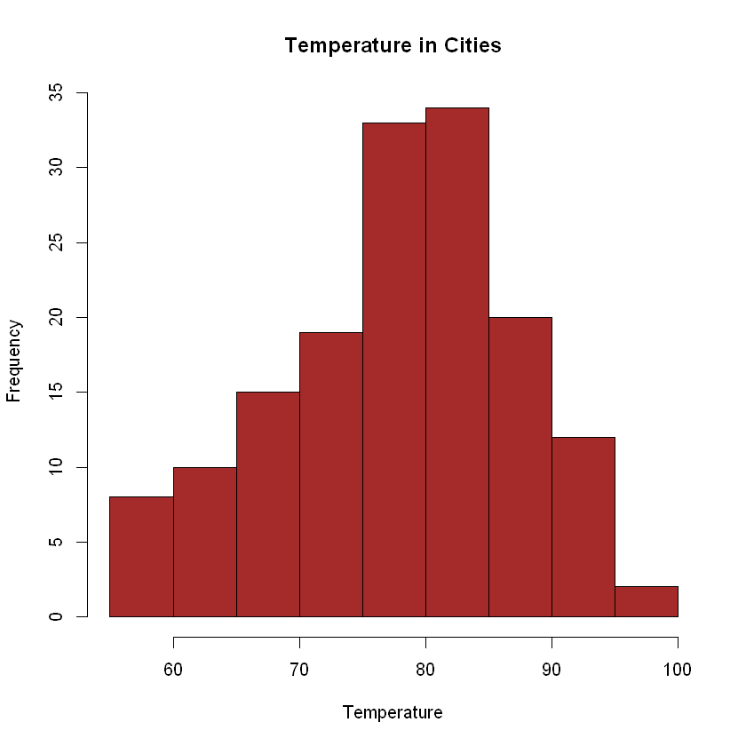

```r
#2.Visualize the data for temperature through histogram. Add color and labels
hist(airquality$Temp,col = 'brown',xlab='Temperature',ylab='Frequency',main = 'Temperature in Cities'  )
```

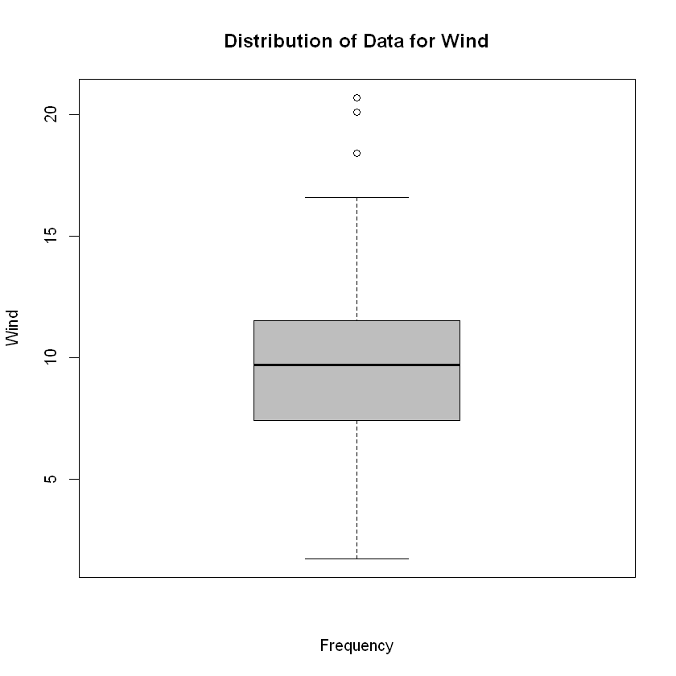

```r
#3.Visualize the distribution of data for Wind. Add colors and labels
boxplot(airquality$Wind,col='grey',xlab='Frequency',ylab = 'Wind',main = "Distribution of Data for Wind")
```

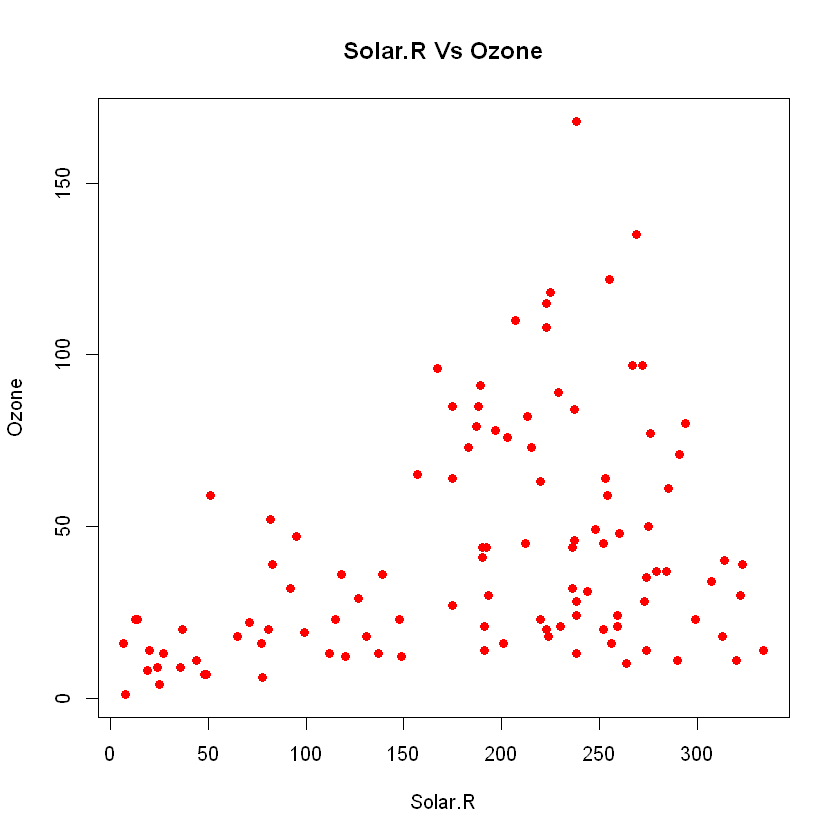

```r
#4.Visualize the relationship between Solar.R and Ozone. Use scatterplot and circular red markers to identify the points.
with(airquality,plot( Solar.R,Ozone,col='red',pch = 19,main = "Solar.R Vs Ozone"))
```

### Good Job! You have completed this section!

## Section 2: Plotting Systems in R: Base, lattice, ggplot2

### Question 1

**The dataset is loaded for you. Perform the following tasks:**

1. Using the state.x77 and state.region datasets, visualize the relationship between Income and illiteracy.
2. Visualize the relationship between Population, region and life expectancy (Life.Exp).
3. Export the charts to a pdf file.

You can use either lattice or ggplot2 libraries to accomplish this task.

```r
library(lattice)
library(ggplot2)
head(state.x77)
head(state.region)
```

|  | Population | Income | Illiteracy | Life Exp | Murder | HS Grad | Frost | Area |
| --- | --- | --- | --- | --- | --- | --- | --- | --- |
| Alabama | 3615 | 3624 | 2.1 | 69.05 | 15.1 | 41.3 | 20 | 50708 |
| Alaska | 365 | 6315 | 1.5 | 69.31 | 11.3 | 66.7 | 152 | 566432 |
| Arizona | 2212 | 4530 | 1.8 | 70.55 | 7.8 | 58.1 | 15 | 113417 |
| Arkansas | 2110 | 3378 | 1.9 | 70.66 | 10.1 | 39.9 | 65 | 51945 |
| California | 21198 | 5114 | 1.1 | 71.71 | 10.3 | 62.6 | 20 | 156361 |
| Colorado | 2541 | 4884 | 0.7 | 72.06 | 6.8 | 63.9 | 166 | 103766 |

1. South

2. West

3. West

4. South

5. West

6. West

**Levels**:**

1. 'Northeast'

2. 'South'

3. 'North Central'

4. 'West'

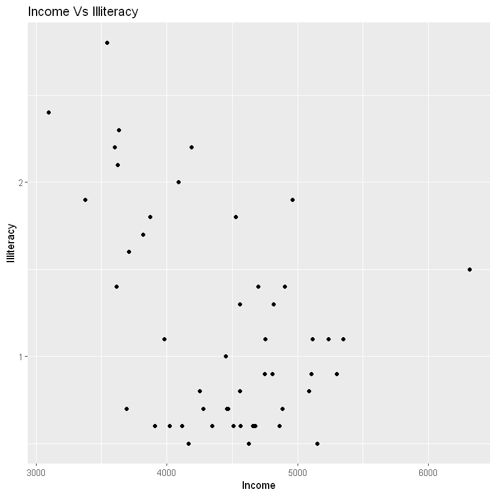

```r
#1.Using the state.x77 and state.region datasets, visualize the relationship between Income and illiteracy.
state <- data.frame(state.x77,region = state.region)
plot <- qplot(Income,Illiteracy,data = state,main= "Income Vs Illiteracy")
print(plot)
```

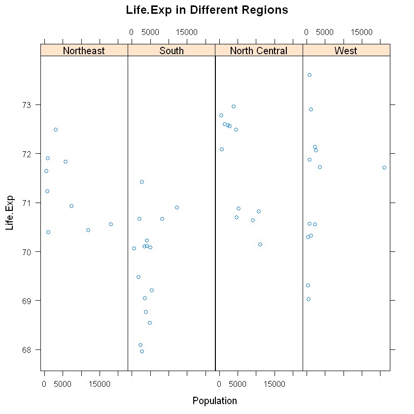

```r
#2.Visualize the relationship between Population, region and life expectancy (Life.Exp).
state <- data.frame(state.x77,region = state.region)
l_plot <- xyplot(Life.Exp ~ Population  | region,data = state ,layout=c(4,1),main = "Life.Exp in Different Regions")
l_plot
```

```r
#3.Export the charts to a pdf file.
pdf("plot.pdf")
print(plot)
dev.off()
```

**png:** 2

```r
#3.Export the charts to a pdf file.
pdf("l_plot.pdf")
print(l_plot)
dev.off()
```

**png:** 2

### Question 2

**The dataset is loaded for you. Perform the following tasks:**

1. Using the visualize the relationship between height and weight from the women dataset.
2. Is there a strong correlation between the two quantities? Compute correlation coefficient and fit a linear regression model.
3. Export the charts and results to a pdf file.

```r
head(women)
data1 <- women
```

| height | weight |
| --- | --- |
| 58 | 115 |
| 59 | 117 |
| 60 | 120 |
| 61 | 123 |
| 62 | 126 |
| 63 | 129 |

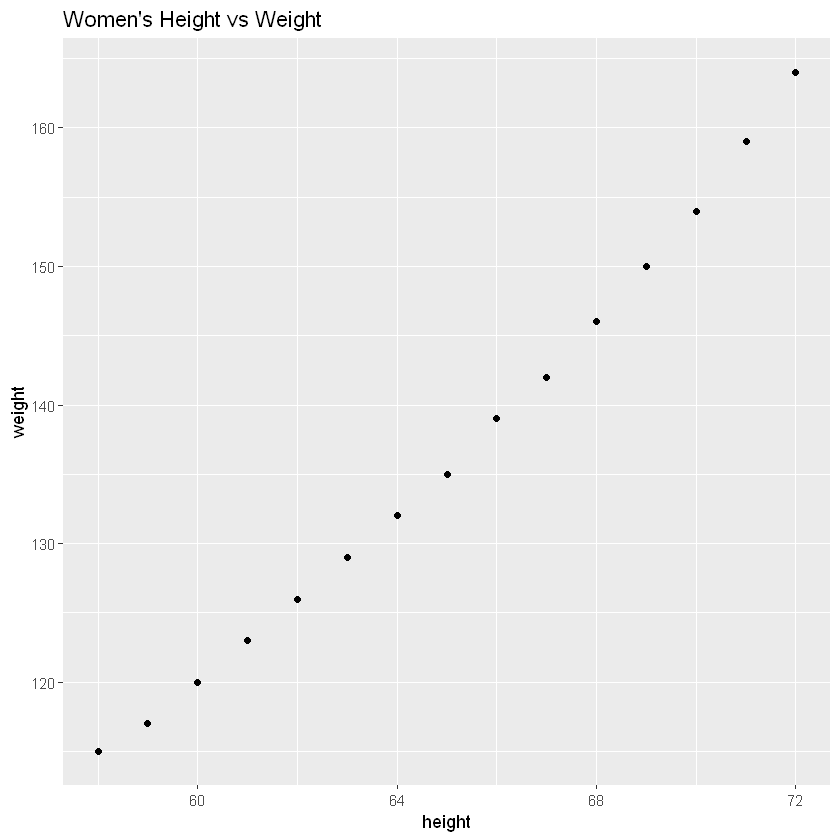

```r
#1.Using the visualize the relationship between height and weight from the women dataset.
g_plot <-  qplot(height,weight,data = data1,main = "Women's Height vs Weight")
g_plot
```

```r
#2.Is there a strong correlation between the two quantities? Compute correlation coefficient and fit a linear regression model.
#Ans.It is clear that women's weight is positively correlated with the height.
co_cof <- lm(weight~height,data = data1)
co_cof
```

```
Call:
lm(formula = weight ~ height, data = data1)

Coefficients:
(Intercept)       height
     -87.52         3.45
```

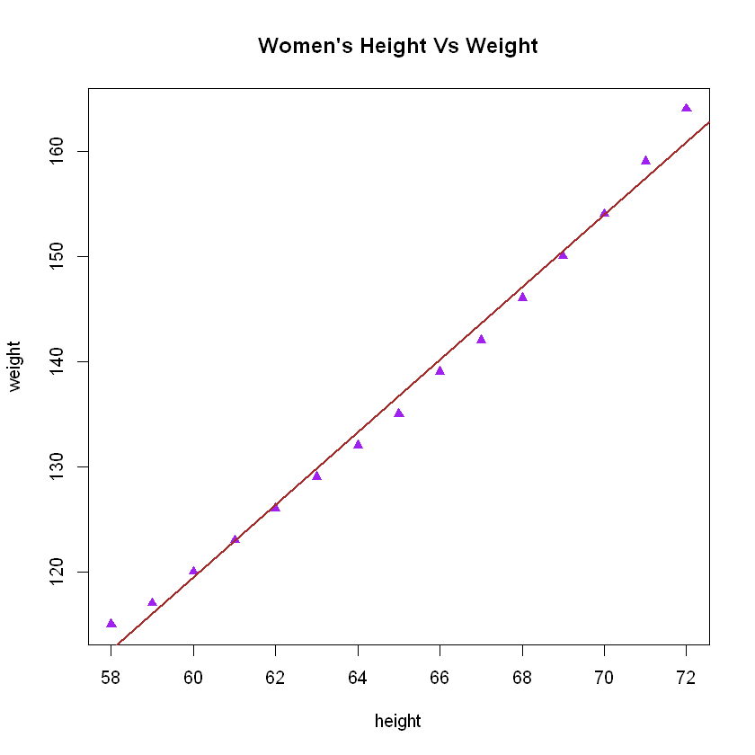

```r
plot(data1$height, data1$weight,main = "Women's Height Vs Weight",col = "purple",xlab = "height",ylab = "weight",pch = 17)
abline(co_cof,lwd = 2,lty = 25,col = "brown")
```

```r
#3.Export the charts and results to a pdf file.
pdf("g_plot.pdf")
print(g_plot)
dev.off()
```

**png:** 2

## Section 3: Aesthetics and Visuals of ggplot2

### Question 1

**The dataset is loaded for you. Perform the following tasks:**

1. Using the longley dataset, plot the relationship between Umployed and GNP.
2. As a scatter plot, plot out Unemployed values as blue dots and Employed values as green dots.
3. Create a new variable as a column known as Armed.Forces.Unemployed.Rel. In it, place a Y for when the number of armed forces are greater than unemployed and N otherwise. Plot a graph to show the relationship between unemployed and armed forces and use the Armed.Forces.Unemployed.Rel for aesthetics and color.

Add appropriate title, axis labels and charts for EACH of the above charts.  
You need to use ggplot2 to accomplish this task.

```r
head(longley)
library(ggplot2)
```

|  | GNP.deflator | GNP | Unemployed | Armed.Forces | Population | Year | Employed |
| --- | --- | --- | --- | --- | --- | --- | --- |
| 1947 | 83.0 | 234.289 | 235.6 | 159.0 | 107.608 | 1947 | 60.323 |
| 1948 | 88.5 | 259.426 | 232.5 | 145.6 | 108.632 | 1948 | 61.122 |
| 1949 | 88.2 | 258.054 | 368.2 | 161.6 | 109.773 | 1949 | 60.171 |
| 1950 | 89.5 | 284.599 | 335.1 | 165.0 | 110.929 | 1950 | 61.187 |
| 1951 | 96.2 | 328.975 | 209.9 | 309.9 | 112.075 | 1951 | 63.221 |
| 1952 | 98.1 | 346.999 | 193.2 | 359.4 | 113.270 | 1952 | 63.639 |

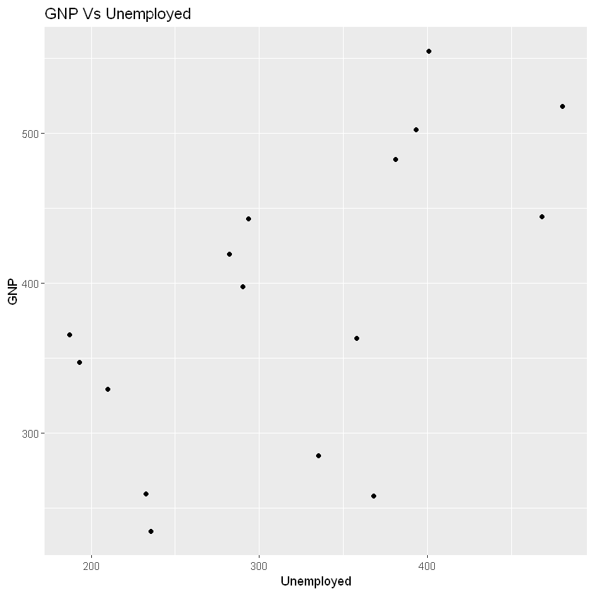

```r
#1.Using the longley dataset, plot the relationship between Umployed and GNP.
graph <- ggplot(longley,aes(Unemployed,GNP))
graph + geom_point() + labs(title = "GNP Vs Unemployed")
```

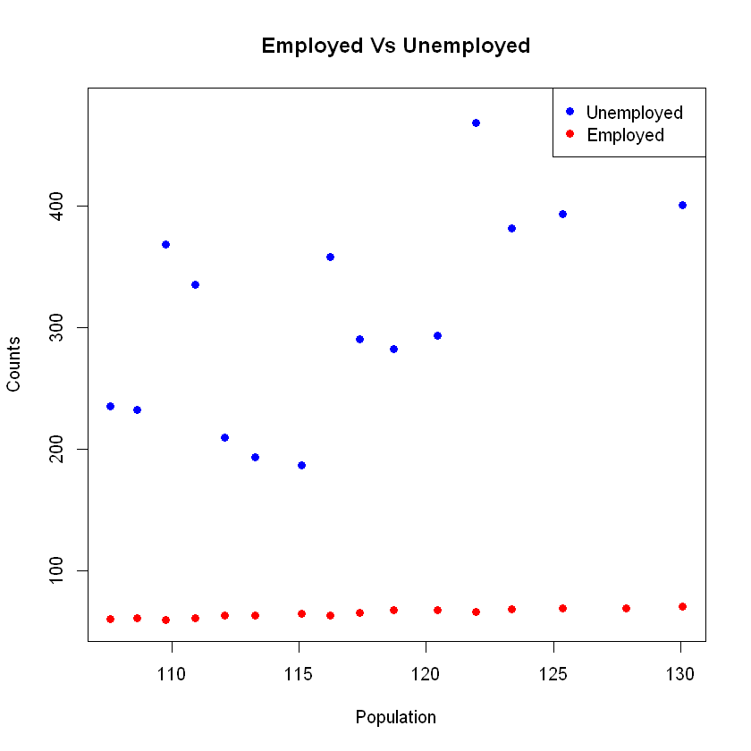

```r
#2.As a scatter plot, plot out Unemployed values as blue dots and Employed values as green dots.
plot(longley$Population,longley$Employed,type = "p",ylim = c(59,480),col = 2,pch = 19,main = "Employed Vs Unemployed",xlab = "Population" ,ylab = "Counts")
points(longley$Population,longley$Unemployed,type = "p", col = 4, pch = 19)
legend("topright",pch = 19,col = c("blue","red"),legend = c("Unemployed","Employed"))
```

1. 'N'

2. 'N'

3. 'N'

4. 'N'

5. 'Y'

6. 'Y'

7. 'Y'

8. 'N'

9. 'Y'

10. 'Y'

11. 'N'

12. 'N'

13. 'N'

14. 'N'

15. 'N'

16. 'N'

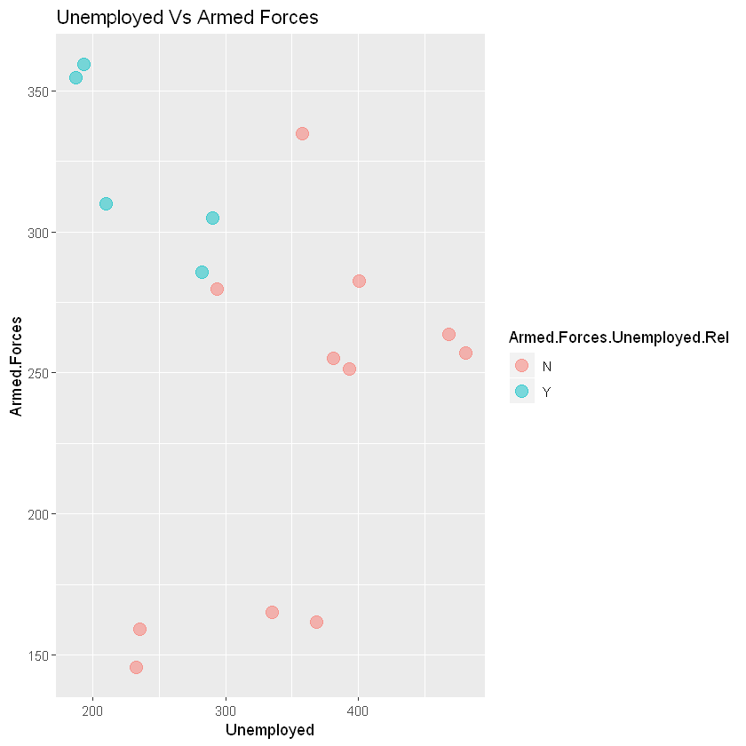

```r
#3.Create a new variable as a column known as Armed.Forces.Unemployed.Rel. In it, place a Y for when the number of
#armed forces are greater than unemployed and N otherwise.Plot a graph to show the relationship between unemployed and
#armed forces and use the Armed.Forces.Unemployed.Rel for aesthetics and color.
Armed.Forces.Unemployed.Rel <- ifelse(longley$Armed.Forces > longley$Unemployed, "Y","N")
Armed.Forces.Unemployed.Rel
gg_plot <- ggplot(longley,aes(Unemployed,Armed.Forces))
gg_plot + geom_point(aes(color = Armed.Forces.Unemployed.Rel),size = 4,alpha = 1/2)+
labs(title = "Unemployed Vs Armed Forces")
```

### Congratulations! You have successfully completed this course and practice exercises!